# week_07_corrplots

## Correlation coefficient

The correlation coefficient is between -1 and +1. A value of -1 means there is a perfect ANTI or NEGATIVE **linear** relationship between the two variables. A +1 means a perfect POSITIVE **linear** relationship.

The correlation matrix can be calculated via the Pandas .corr method.

```python
penguins.loc[:, ["flipper_length_mm", "bill_depth_mm"]].corr()
```

|  | flipper_length_mm | bill_depth_mm |
| --- | --- | --- |
| flipper_length_mm | 1.000000 | -0.583851 |
| bill_depth_mm | -0.583851 | 1.000000 |

CORRELATION is representing LINEAR relationships!!!!

I dont like looking at numbers in TABLES! I instead prefer to VISUALIZE things!!

Lets visualize the correclation matrix as a HEAT MAP!!

The HEAT MAP is given a special name. It's called the **CORRELATION PLOT** OR **CORRPLOT** FOR SHORT!

We need to use the sns.heatmap() function to make the CORRPLOT. The sns.heatmap function is an AXIS level function.

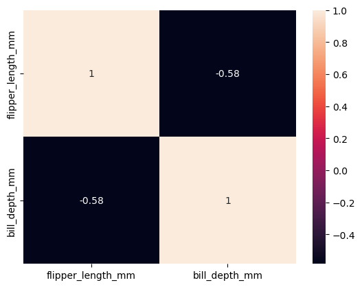

```python
fig, ax = plt.subplots()

sns.heatmap(data=penguins.loc[:, ["flipper_length_mm", "bill_depth_mm"]].corr(),
            ax=ax,
           annot=True)

plt.show()
```

But you should never use the default bounds on the color scale!!!

You must always define the BOUNDS on the color scale to be between -1 and +1 when visualizing CORRPLOTS!!!

The bounds are controlled by the vmin and vmax arguments to sns.heatmap().

AND you should set the center argument which controls MIDPOINT value between the lower (vmin) and upper (vmax) color bounds.

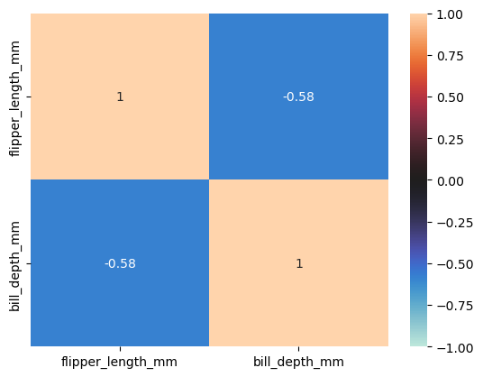

```python
fig, ax = plt.subplots()

sns.heatmap(data=penguins.loc[:, ["flipper_length_mm", "bill_depth_mm"]].corr(),
            ax=ax,
           vmin=-1,
           vmax=1,
           center=0,
           annot=True)

plt.show()
```

Diverging color palettes are important to use for CORRPLOTS because we want to focus on behavior AWAY from the MIDPOINT of a correlation coefficient of 0. A diverging color palette lets us distinguish the SIGN based on color while still representing the MAGNITUDE by the color intensity/darkness.

The default color palete is "icefire". The palette can be changed with the cmap argument.

```python
fig, ax = plt.subplots()

sns.heatmap(data=penguins.loc[:, ["flipper_length_mm", "bill_depth_mm"]].corr(),
            ax=ax,
           vmin=-1,
           vmax=1,
           center=0,
           annot=True)

plt.show()
```

[output not shown]

But there are more divering color palettes. I like "coolwarm".

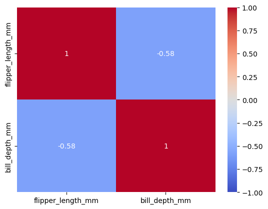

```python
fig, ax = plt.subplots()

sns.heatmap(data=penguins.loc[:, ["flipper_length_mm", "bill_depth_mm"]].corr(),
            ax=ax,
           vmin=-1,
           vmax=1,
           center=0,
           annot=True,
           cmap="coolwarm")

plt.show()
```

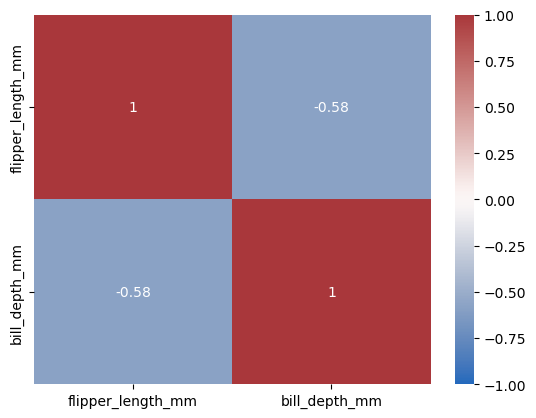

```python
fig, ax = plt.subplots()

sns.heatmap(data=penguins.loc[:, ["flipper_length_mm", "bill_depth_mm"]].corr(),
            ax=ax,
           vmin=-1,
           vmax=1,
           center=0,
           annot=True,
           cmap="vlag")

plt.show()
```

You can ANNOTATE the CORRPLOT via TEXT to make it easier to display the correlation coefficient!!

Use the ANNOTATE text to show the EXACT correlation coefficient!!

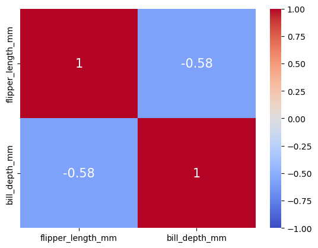

```python
fig, ax = plt.subplots()

sns.heatmap(data=penguins.loc[:, ["flipper_length_mm", "bill_depth_mm"]].corr(),
            ax=ax,
           vmin=-1,
           vmax=1,
           center=0,
           annot=True, annot_kws={"size": 15},
           cmap="coolwarm")

plt.show()
```

This is for showing 2 specific variables corr coefficient.

We can change to 2 others...

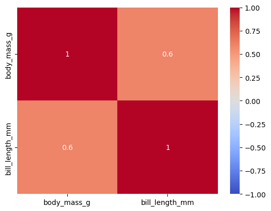

```python
fig, ax = plt.subplots()

sns.heatmap(data=penguins.loc[:, ["body_mass_g", "bill_length_mm"]].corr(),
            ax=ax,
           vmin=-1,
           vmax=1,
           center=0,
           annot=True,
           cmap="coolwarm")

plt.show()
```

BUT..correlation plots are particularly great for showing the relationship between more than just 2 continuous variables...

We can show the correlation coefficient between ALL pairs of contunous variables in one chart!!!

```python
penguins.corr(numeric_only=True)
```

|  | bill_length_mm | bill_depth_mm | flipper_length_mm | body_mass_g |
| --- | --- | --- | --- | --- |
| bill_length_mm | 1.000000 | -0.235053 | 0.656181 | 0.595110 |
| bill_depth_mm | -0.235053 | 1.000000 | -0.583851 | -0.471916 |
| flipper_length_mm | 0.656181 | -0.583851 | 1.000000 | 0.871202 |
| body_mass_g | 0.595110 | -0.471916 | 0.871202 | 1.000000 |

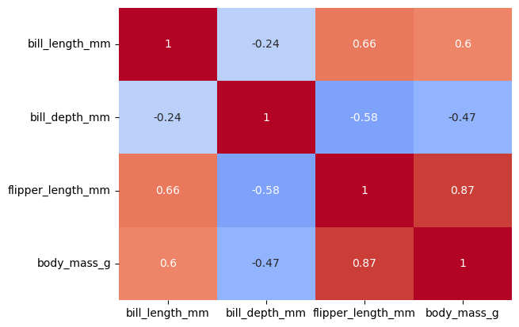

```python
fig, ax = plt.subplots()

sns.heatmap(data=penguins.corr(numeric_only=True),
            ax=ax,
           vmin=-1,
           vmax=1,
           center=0, cbar=False,
           annot=True,
           cmap="coolwarm")

plt.show()
```

## GROUPING

Remember we saw that GROUPING BY a cat CHANGED our opinion about the relationship between two continuous variables!

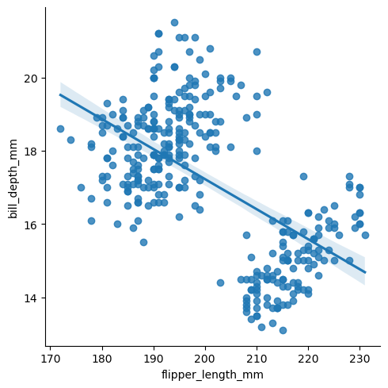

```python
sns.lmplot(data=penguins, x="flipper_length_mm", y="bill_depth_mm")

plt.show()
```

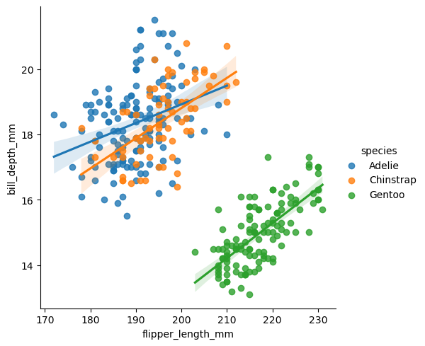

```python
sns.lmplot(data=penguins, x="flipper_length_mm", y="bill_depth_mm", hue="species")

plt.show()
```

We can group by a cat variable and apply the corr method to get the correlation matrix for each category!!

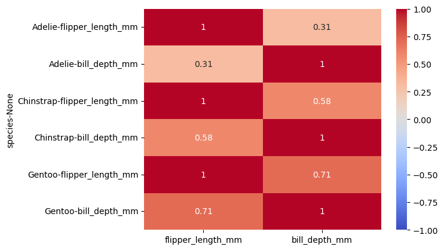

```python
fig, ax = plt.subplots()

sns.heatmap(data=penguins.loc[:, ["flipper_length_mm", "bill_depth_mm", "species"]].groupby(['species']).corr(),
            ax=ax,
           vmin=-1,
           vmax=1,
           center=0,
           annot=True,
           cmap="coolwarm")

plt.show()
```

We can visualize the GROUPED correlation plot by iterating over the GROUPS via a for-loop and applying the sns.heatmap() function to that group!!

sns.heatmap() is AXIS level function. It will not generate facets for us!!!

ITs useful to define helper objects to store the GROUPs we will iterate over.

```python
the_groups = penguins.species.unique().tolist()
```

```python
the_groups
```

```
['Adelie', 'Chinstrap', 'Gentoo']
```

```python
corr_per_group = penguins.loc[:, ["flipper_length_mm", "bill_depth_mm", "species"]].groupby(["species"]).corr()
```

```python
corr_per_group
```

| species |  | flipper_length_mm | bill_depth_mm |
| --- | --- | --- | --- |
| Adelie | flipper_length_mm | 1.000000 | 0.307620 |
|  | bill_depth_mm | 0.307620 | 1.000000 |
| Chinstrap | flipper_length_mm | 1.000000 | 0.580143 |
|  | bill_depth_mm | 0.580143 | 1.000000 |
| Gentoo | flipper_length_mm | 1.000000 | 0.706563 |
|  | bill_depth_mm | 0.706563 | 1.000000 |

```python
corr_per_group.loc["Adelie"]
```

|  | flipper_length_mm | bill_depth_mm |
| --- | --- | --- |
| flipper_length_mm | 1.00000 | 0.30762 |
| bill_depth_mm | 0.30762 | 1.00000 |

One facet (subplot) per grouping value.

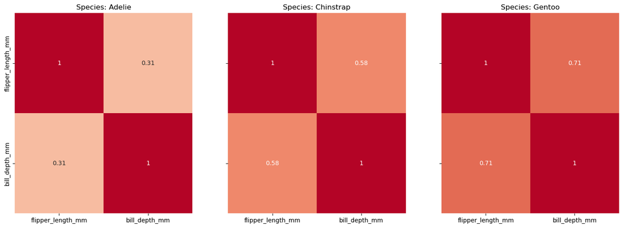

```python
fig, axs = plt.subplots(1, len(the_groups), figsize=(18,6), sharex=True, sharey=True)

for ix in range(len(the_groups)):
    sns.heatmap(data=corr_per_group.loc[the_groups[ix]],
                vmin=-1, vmax=1, center=0,
                annot=True, cmap="coolwarm",
                cbar=False, ax=axs[ix])

    axs[ix].set_title("Species: %s" % the_groups[ix])

plt.show()
```

We can create GROUPED correlation plots between more than just 2 continuous variables!!

```python
corr_per_group_all = penguins.groupby("species").corr(numeric_only=True)
```

```python
corr_per_group_all
```

| species |  | bill_length_mm | bill_depth_mm | flipper_length_mm | body_mass_g |
| --- | --- | --- | --- | --- | --- |
| Adelie | bill_length_mm | 1.000000 | 0.391492 | 0.325785 | 0.548866 |
|  | bill_depth_mm | 0.391492 | 1.000000 | 0.307620 | 0.576138 |
|  | flipper_length_mm | 0.325785 | 0.307620 | 1.000000 | 0.468202 |
|  | body_mass_g | 0.548866 | 0.576138 | 0.468202 | 1.000000 |
| Chinstrap | bill_length_mm | 1.000000 | 0.653536 | 0.471607 | 0.513638 |
|  | bill_depth_mm | 0.653536 | 1.000000 | 0.580143 | 0.604498 |
|  | flipper_length_mm | 0.471607 | 0.580143 | 1.000000 | 0.641559 |
|  | body_mass_g | 0.513638 | 0.604498 | 0.641559 | 1.000000 |
| Gentoo | bill_length_mm | 1.000000 | 0.643384 | 0.661162 | 0.669166 |
|  | bill_depth_mm | 0.643384 | 1.000000 | 0.706563 | 0.719085 |
|  | flipper_length_mm | 0.661162 | 0.706563 | 1.000000 | 0.702667 |
|  | body_mass_g | 0.669166 | 0.719085 | 0.702667 | 1.000000 |

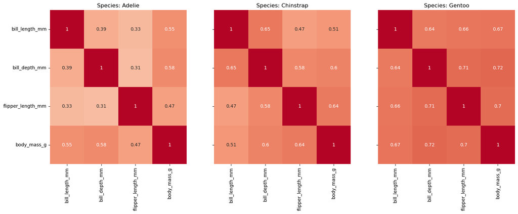

```python
fig, axs = plt.subplots(1, len(the_groups), figsize=(18,6), sharex=True, sharey=True)

for ix in range(len(the_groups)):
    sns.heatmap(data=corr_per_group_all.loc[the_groups[ix]],
                vmin=-1, vmax=1, center=0, cbar=False, cmap="coolwarm", annot=True,
                ax=axs[ix])
    axs[ix].set_title("Species: %s" % the_groups[ix])

plt.show()
```